# Part 1 - Extract and Transform

```python
!pip install findspark
```

```python
!pip install pyspark
```

```python
# importing
import os
import re
import findspark
findspark.init()
from pyspark.sql import SparkSession
from pyspark.sql.functions import substring
from pyspark.sql.functions import from_json
from pyspark.sql.functions import col,lit
from pyspark.sql.functions import when
from pyspark.sql.functions import size
from pyspark.sql.functions import array_remove
from pyspark.sql import functions as f
import pandas as pd
import matplotlib.pyplot as plt
import numpy as np
from os import path
from PIL import Image
from wordcloud import WordCloud, STOPWORDS, ImageColorGenerator
from IPython.display import display_html
from pyspark.sql.types import StructField, StructType, StringType, DoubleType, IntegerType , DataType ,LongType , ArrayType , json , DateType

def init_spark(app_name: str):
  spark = SparkSession.builder.appName(app_name).getOrCreate()
  sc = spark.sparkContext
  return spark, sc

spark, sc = init_spark('demo')
sc
```

**SparkContext**

[Spark UI](http://42e8c92151e8:4040)

**Version**

`v3.2.1`

**Master**

`local[*]`

**AppName**

`demo`

```python
#files
file_credits='credits.csv'
file_movies='movies.csv'
file_queries='queries.csv'
file_tickets='tickets.csv'
file_users='users.csv'
```

```python
#loading the users file
users = spark.read.option("Header", "true")\
        .option("multiline", "true")\
        .option("escape", "\"")\
        .csv(file_users)
```

```python
#loading the movies file
movies = spark.read.option("Header", "true")\
        .option("multiline", "true")\
        .option("escape", "\"")\
        .csv(file_movies)
#transformations for movies
## dropping irrelevant columns
cols_to_drop_movies = ['overview', 'revenue', 'tagline']
movies = movies.drop(*cols_to_drop_movies)

##extracting from relase_date column the year
movies = movies.withColumn('release_date', substring('release_date', 7,9))

##extracting necessary information from the structured columns
columns = ['genres', 'production_companies', 'production_countries', 'spoken_languages', 'cities']
schema = ['array<struct<id:int , name:string>>',
              'array<struct<name:string, id:int>>',
              'array<struct<iso_3166_1:string , name:string>>',
              'array<struct<iso_639_1:string , name:string>>',
              'array<string>']

for column, field in zip(columns, schema):
    movies = movies.withColumn(column, from_json(col(column), lit(field)))

movies = movies.withColumn('genres', movies.genres['name']).withColumn('production_companies', movies.production_companies['name'])\
    .withColumn('production_countries', movies.production_countries['name']).withColumn('spoken_languages', movies.spoken_languages['name'])\
    .withColumn('spoken_languages', array_remove('spoken_languages', "?????")).withColumn('spoken_languages', array_remove('spoken_languages', "??????"))\
    .withColumn('spoken_languages', array_remove('spoken_languages',''))
```

```python
#loading the credits file using pandas and regex
credits_pd = pd.read_csv('credits.csv')
credits_pd['cast']= [ re.findall("(?<='name':\s)'[\w]*[(\._\-\s)*\w*]*'", i, flags=0) for i in credits_pd['cast'] ]
credits_pd['crew']= [ re.findall("(?<='Director', 'name':\s)'[\w]*[(\._\-\s)*\w*]*'", i, flags=0) for i in credits_pd['crew'] ]
credits =  spark.createDataFrame(credits_pd)
```

```python
#loading the queries file
queries = spark.read.option("Header", "true")\
        .option("multiline", "true")\
        .option("escape", "\"")\
        .csv(file_queries)

##extracting from relase_date column the year
queries = queries.withColumn('from_realese_date', substring('from_realese_date', 3,4))
```

```python
#loading the tickets file
tickets = spark.read.option("Header", "true")\
        .option("multiline", "true")\
        .option("escape", "\"")\
        .csv(file_tickets)

cols_to_drop_tickets = ['cinema_id']
tickets = tickets.drop(*cols_to_drop_tickets)
```

# **Part 2 - Data Analysis**

### We will analyze the distribution of users by city and understand their behavior (regarding querying for movies and ordering tickets for movies).

### Insights:

1. We want to know what is the percentage of users in each city that are searching movies that are available in certain cities (For example, we can note that users from Eilat searched only for movies from Eilat) - it helps us divide the movies according to what the users are searching the most.
2. We examined the percentage of queries that users from Eilat were looking movies by actors and we found out that no one was searching by actors in their query - we can remove the actors column from Eilat.
3. We checked the percentage of queries that users from Jerusalem were looking for movies by actors and we found out that they are heavily looking for movies by actors (users from Tel Aviv, Kibuts Gesher and Haifa searched for it 50% of the queries - we think it's also a lot), and they search especially for:
   - Johnny Depp
   - Brad Pitt
   - Tom Hanks
4. We examined the percentage of queries that users from Haifa were looking for movies by directors and we found out that more than 91 percent of Haifa's queries contain a search by director.
5. We examined the percentage of queries that users were looking for production countries and we found out that users from Eilat, Kibuts Gesher and Jerusalem are always searching for movies accroding to the countries it was produced in(users from Haifa and Tel Aviv significantly less).
6. We checked what users from certain city are searching for movies in Hebrew and we found that more than 85 percent of Jerusalem's queries got the Hebrew language while the other queries are less than 1% - Therefore, we would like to put the films that are available in the Hebrew language in Jerusalem.
7. We checked what users from certain city are searching for movies that were produced in Israel and we found that users from Jerusalem are searching for it significantly more than users in other cities.
8. We checked for each location what is the oldest year the users searched for - for Tel Aviv and Haifa is 2010, for other is 1990. Therefore, the oldest year users searched for is 1990.
9. We examined the production companies that users were looking for and we found out that users from Eilat are searching for it significantly more than users in other cities.
10. We examined the genres that users were looking for and we found out that users from Tel Aviv are searching a lot by the "Action" genre, users from Haifa search a lot b the "Drama" genre and users from kibuts Gesher search a lot by the "Family" and "Documentary" genres

### Optimizer:

1. We made an optimizer that calculates the average amount of entries in each field sort and separated by residents of each city. This is used to find the most optimized way to sort and secondary sort database (allowing binary search and minimizing amount of repeat big searches).

### We will start by answering the following questions:

1. What is the percentage of users in each city
2. What is the number of queries in each city, the number of ticket buying - Comparison of distributions

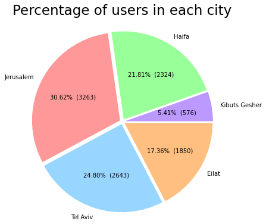

```python
#question1
def make_autopct(values):
    def my_autopct(pct):
        total = sum(values)
        val = int(round(pct*total/100.0))
        return '{p:.2f}%  ({v:d})'.format(p=pct,v=val)
    return my_autopct

users_per_city = users.groupBy("user_location").count()
df = users_per_city.toPandas()
city_count = df['count'].to_list()
cities = df['user_location'].unique()
colors1 = ["#bb99ff", "#99ff99", "#ff9999", "#99d6ff", "#ffbf80"]
plt.pie(city_count, labels = cities,autopct=make_autopct(df['count']),
        explode = [0.05 for _ in cities], radius = 1.7, colors = colors1)
plt.title("Percentage of users in each city", fontdict={'fontsize': 23}, y=1.3)
plt.show()
```

### With the help of this pie we can see the distribution of users by city.

- For example, it can be seen that most users live in Jerusalem

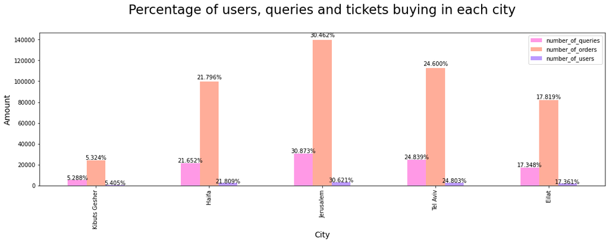

```python
#question2
users_per_city = users.groupBy("user_location").count()\
.withColumnRenamed("count", "number_of_users")
tickets_location = tickets.join(users, tickets.user_id == users.user_id)
tickets_by_location = tickets_location.groupBy("user_location").count()\
.withColumnRenamed("count", "number_of_orders")
queries_location = queries.join(users, queries.user_id == users.user_id)
queries__by_location = queries_location.groupBy("user_location").count()\
.withColumnRenamed("count", "number_of_queries")
queries_tickets_location = queries__by_location.join(tickets_by_location,\
queries__by_location.user_location == tickets_by_location.user_location)\
.drop(tickets_by_location.user_location)
queries_tickets__users_location = queries_tickets_location.join(users_per_city,\
queries_tickets_location.user_location == users_per_city.user_location)\
.drop(queries_tickets_location.user_location)
df = queries_tickets__users_location.toPandas()
colors2 = ["#ff99e6", "#ffad99", "#bb99ff"]
ax = df.plot(kind='bar', x="user_location", figsize=(18,5), color=colors2)
plt.title("Percentage of users, queries and tickets buying in each city",\
          fontdict={'fontsize': 23}, y = 1.1)
plt.xlabel("City", fontdict={'fontsize': 14})
plt.ylabel("Amount", fontdict={'fontsize': 14})
for p in ax.patches:
    width = p.get_width()
    height = p.get_height()
    lst = [5288, 21652, 30873, 24839, 17348]
    lst2 = [24411, 99942, 139679, 112802, 81706]
    if height in lst:
      x, y = p.get_xy()
      ax.annotate(f'{height/queries_location.count():.3%}',\
                  (x + width/2, y + height*1.02), ha='center')
    elif height in lst2:
      x, y = p.get_xy()
      ax.annotate(f'{height/tickets_location.count():.3%}',\
                  (x + width/2, y + height*1.02), ha='center')
    else:
      x, y = p.get_xy()
      ax.annotate(f'{height/users.count():.3%}',\
                  (x + width/2, y + height*1.02), ha='center')

plt.show()
```

### We can see that:

- There is an identical distribution in each city between number of users, number of queries and number of tickets buying.
  - For example, there are 30.62 percent of users who live in Jerusalem, 30.462 percent of the ticket buying were made by them and 30.873 percent of the queries were made by them.

### Now we can start to comprehend the insights.

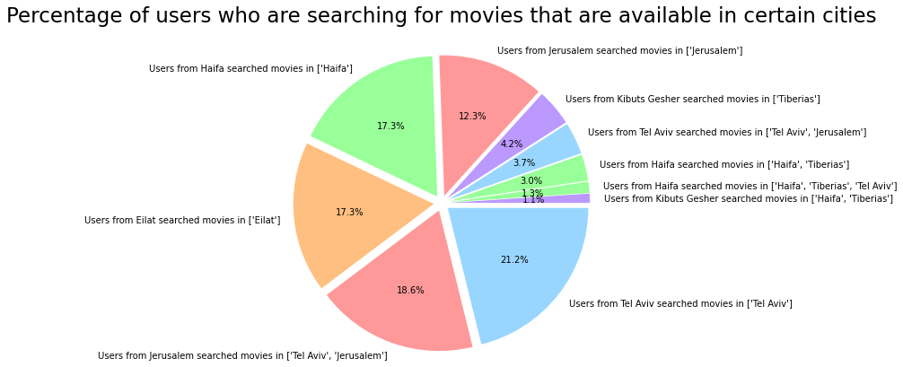

```python
#insight1
queries_location = queries.join(users, queries.user_id == users.user_id)
queries_by_location = queries_location.groupBy("user_location","cities").\
count().sort("count")
df = queries_by_location.toPandas()
city_count = df['count'].to_list()
cities = df['cities'].unique()
labels = "Users from " + df["user_location"] + " searched movies in " +\
df["cities"].map(str)
colors3 = ["#bb99ff", "#99ff99","#99ff99", "#99d6ff","#bb99ff", "#ff9999", "#99ff99","#ffbf80", "#ff9999", "#99d6ff"]
plt.pie(city_count,
        labels = labels,
        autopct = "%1.1f%%",
        explode = [0.1 for _ in labels], radius=1.8, colors = colors3)
plt.title("Percentage of users who are searching for movies that are available in certain cities", fontdict={'fontsize': 23}, y = 1.4)
plt.show()
```

```python
#continue of insight1

#style
style = [{'selector': 'caption','props': [('background', '#ffdf80'),\
('color', 'Black'),('font-family', 'verdana'), ("font-size", "150%")]},
 {'selector': 'th','props': [('background', '#3399ff'), ('color', 'Black'),\
                             ('font-family', 'verdana')]},
 {'selector': 'td','props': [('color', 'BLACK'),('font-family', 'verdana')]},
 {'selector': 'tr:nth-of-type(odd)','props': [('background', 'WHITE')]},
 {'selector': 'tr:nth-of-type(even)','props': [('background', 'WHITE')]},
 {'selector': 'tr:hover','props': [('background-color', '#80bfff')]}]

queries_location = queries.join(users, queries.user_id == users.user_id)
queries_by_location = queries_location.groupBy("user_location","cities").\
count().sort("count")
queries_by_haifa = queries_by_location.filter(queries_location['user_location']\
                                      == "Haifa").sort(col("count").desc())
queries_by_eilat = queries_by_location.filter(queries_location['user_location']\
                                      == "Eilat").sort(col("count").desc())
queries_by_tel_aviv = queries_by_location.filter(queries_location['user_location']\
                                      == "Tel Aviv").sort(col("count").desc())
queries_by_kibuts_gesher = queries_by_location.filter(queries_location['user_location']\
                                      == "Kibuts Gesher").sort(col("count").desc())
queries_by_jerusalem = queries_by_location.filter(queries_location['user_location']\
                                      == "Jerusalem").sort(col("count").desc())
df_haifa = queries_by_haifa.toPandas()
df_eilat = queries_by_eilat.toPandas()
df_tel_aviv= queries_by_tel_aviv.toPandas()
df_kibuts_gesher = queries_by_kibuts_gesher.toPandas()
df_jerusalem= queries_by_jerusalem.toPandas()

haifa = df_haifa.head(10).style.set_table_attributes("style='display:inline'").\
set_caption('Queries by users from Haifa').set_table_styles(style).\
hide_index()

eilat = df_eilat.head(10).style.set_table_attributes("style='display:inline'").\
set_caption('Queries by users from Eilat').set_table_styles(style).\
hide_index()

tel_aviv = df_tel_aviv.head(10).style.set_table_attributes("style='display:inline'").\
set_caption('Queries by users from Tel Aviv').set_table_styles(style).\
hide_index()

kibuts_gesher = df_kibuts_gesher.head(10).style.set_table_attributes("style='display:inline'").\
set_caption('Queries by users from Kibuts Gesher').set_table_styles(style).\
hide_index()

jerusalem = df_jerusalem.head(10).style.set_table_attributes("style='display:inline'").\
set_caption('Queries by users from Jerusalem').set_table_styles(style).\
hide_index()
display_html(haifa._repr_html_() + tel_aviv._repr_html_(), raw=True)
display_html(kibuts_gesher._repr_html_() + jerusalem._repr_html_()+ eilat._repr_html_(), raw=True)
```

Queries by users from Haifa

| user_location | cities | count |
| --- | --- | --- |
| Haifa | ['Haifa'] | 17346 |
| Haifa | ['Haifa', 'Tiberias'] | 3012 |
| Haifa | ['Haifa', 'Tiberias', 'Tel Aviv'] | 1294 |

Queries by users from Tel Aviv

| user_location | cities | count |
| --- | --- | --- |
| Tel Aviv | ['Tel Aviv'] | 21151 |
| Tel Aviv | ['Tel Aviv', 'Jerusalem'] | 3688 |

Queries by users from Kibuts Gesher

| user_location | cities | count |
| --- | --- | --- |
| Kibuts Gesher | ['Tiberias'] | 4228 |
| Kibuts Gesher | ['Haifa', 'Tiberias'] | 1060 |

Queries by users from Jerusalem

| user_location | cities | count |
| --- | --- | --- |
| Jerusalem | ['Tel Aviv', 'Jerusalem'] | 18588 |
| Jerusalem | ['Jerusalem'] | 12285 |

Queries by users from Eilat

| user_location | cities | count |
| --- | --- | --- |
| Eilat | ['Eilat'] | 17348 |

### We can see that:

- Users who live in Haifa are mostly searching for movies in Haifa and also searching for movies in Tiberias and Tel Aviv
- Users who live in Tel Aviv are mostly searching for movies in Tel Aviv and also searching for movies in Jerusalem
- Users who live in Kibuts Gesher are mostly searching for movies in Tiberias and also searching for movies in Haifa
- Users who live in Jerusalem are mostly searching for movies in Jerusalem and Tel Aviv and also searching for movies in Jerusalem
- Users who live in Eilat are only searching for movies in Eilat

```python
#insight2
queries_user = queries.join(users, queries.user_id == users.user_id)
actors_by_eilat = queries_user.groupBy("user_location","actors").count().\
sort(col("count").desc()).filter(queries_user['user_location'] == "Eilat").\
withColumnRenamed("count", "number_of_queries").drop(queries_user.user_location)
df_actors_by_eilat = actors_by_eilat.toPandas()
eilat = df_actors_by_eilat.head(10).style.\
set_caption('Queries by actors of users from Eilat').set_table_styles(style).\
hide_index()
display_html(eilat._repr_html_() , raw=True)
```

Queries by actors of users from Eilat

| actors | number_of_queries |
| --- | --- |
| [] | 17348 |

### We can see that:

- No one from Eilat searched for movies by actors in their queries

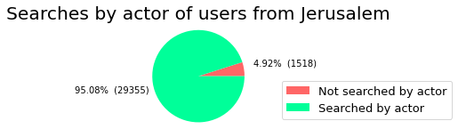

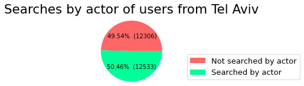

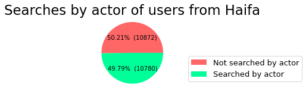

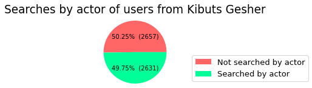

```
Word Cloud of actors that users from Jerusalem searched the most:
Just a cool visualization :)
```

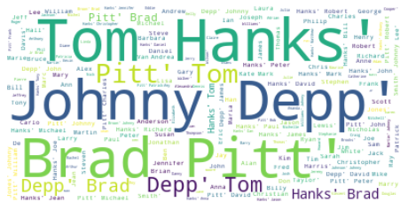

```python
#insight3
colors4 = ['#ff6666','#00ff99']
queries_user = queries.join(users, queries.user_id == users.user_id)
#jerusalem
actors_by_jerusalem = queries_user.groupBy("user_location","actors").count().\
sort(col("count").desc()).\
filter(queries_user['user_location'] == "Jerusalem").\
drop(queries_user.user_location).withColumnRenamed("count", "Number_of_queries")
searched_actors_by_jerusalem = actors_by_jerusalem.\
where(actors_by_jerusalem.actors != "[]").groupBy().sum()
not_actors_by_jerusalem = actors_by_jerusalem.\
where(actors_by_jerusalem.actors == "[]").drop(actors_by_jerusalem.actors)
df_actors_by_jerusalem = actors_by_jerusalem.toPandas()
df_searched_actors_by_jerusalem = searched_actors_by_jerusalem.toPandas()
df_not_actors_by_jerusalem = not_actors_by_jerusalem.toPandas()
c = df_not_actors_by_jerusalem['Number_of_queries'].\
to_list() + df_searched_actors_by_jerusalem['sum(Number_of_queries)'].to_list()
label = ["Not searched by actor", "Searched by actor"]
plt.figure(figsize = (3,2))
pie = plt.pie(c, labels = None, autopct=make_autopct(c),\
              pctdistance=1.9,radius = 2, colors = colors4)
plt.title("Searches by actor of users from Jerusalem",\
          fontdict={'fontsize': 20.2}, y = 1.4)
plt.legend(pie[0],label, bbox_to_anchor=(1.5,0.5), loc="upper right",\
           fontsize=13, bbox_transform=plt.gcf().transFigure)
plt.subplots_adjust(left=0.0, bottom=0.1, right=0.3)
plt.show()

#tel aviv
actors_by_tel_aviv = queries_user.groupBy("user_location","actors").count().\
sort(col("count").desc()).filter(queries_user['user_location'] == "Tel Aviv").\
drop(queries_user.user_location).withColumnRenamed("count", "Number_of_queries")
searched_actors_by_tel_aviv = actors_by_tel_aviv.\
where(actors_by_tel_aviv.actors != "[]").groupBy().sum()
not_actors_by_tel_aviv = actors_by_tel_aviv.\
where(actors_by_tel_aviv.actors == "[]").drop(actors_by_tel_aviv.actors)
df_searched_actors_by_tel_aviv = searched_actors_by_tel_aviv.toPandas()
df_not_actors_by_tel_aviv = not_actors_by_tel_aviv.toPandas()
c = df_not_actors_by_tel_aviv['Number_of_queries'].\
to_list() + df_searched_actors_by_tel_aviv['sum(Number_of_queries)'].to_list()
plt.figure(figsize = (3,2))
pie = plt.pie(c, labels = None, autopct=make_autopct(c),\
              pctdistance=0.5,radius = 2, colors = colors4)
plt.title("Searches by actor of users from Tel Aviv",\
          fontdict={'fontsize': 21.5}, y = 1.4)
plt.legend(pie[0],label, bbox_to_anchor=(1.5,0.5), loc="upper right",\
           fontsize=13, bbox_transform=plt.gcf().transFigure)
plt.subplots_adjust(left=0.0, bottom=0.1, right=0.3)
plt.show()

#haifa
actors_by_haifa = queries_user.groupBy("user_location","actors").count().\
sort(col("count").desc()).filter(queries_user['user_location'] == "Haifa").\
drop(queries_user.user_location).withColumnRenamed("count", "Number_of_queries")
searched_actors_by_haifa = actors_by_haifa.\
where(actors_by_haifa.actors != "[]").groupBy().sum()
not_actors_by_haifa = actors_by_haifa.\
where(actors_by_haifa.actors == "[]").drop(actors_by_haifa.actors)
df_searched_actors_by_haifa = searched_actors_by_haifa.toPandas()
df_not_actors_by_haifa = not_actors_by_haifa.toPandas()
c = df_not_actors_by_haifa['Number_of_queries'].\
to_list() + df_searched_actors_by_haifa['sum(Number_of_queries)'].to_list()
plt.figure(figsize = (3,2))
pie = plt.pie(c, labels = None, autopct=make_autopct(c),\
              pctdistance=0.5,radius = 2, colors = colors4)
plt.title("Searches by actor of users from Haifa",\
          fontdict={'fontsize': 22.8}, y = 1.4)
plt.legend(pie[0],label, bbox_to_anchor=(1.5,0.5), loc="upper right",\
           fontsize=13, bbox_transform=plt.gcf().transFigure)
plt.subplots_adjust(left=0.0, bottom=0.1, right=0.3)
plt.show()

#kibuts_gesher
actors_by_kibuts_gesher = queries_user.groupBy("user_location","actors").\
count().sort(col("count").desc()).\
filter(queries_user['user_location'] == "Kibuts Gesher").\
drop(queries_user.user_location).withColumnRenamed("count", "Number_of_queries")
searched_actors_by_kibuts_gesher = actors_by_kibuts_gesher.\
where(actors_by_kibuts_gesher.actors != "[]").groupBy().sum()
not_actors_by_kibuts_gesher = actors_by_kibuts_gesher.\
where(actors_by_kibuts_gesher.actors=="[]").drop(actors_by_kibuts_gesher.actors)
df_searched_actors_by_kibuts_gesher=searched_actors_by_kibuts_gesher.toPandas()
df_not_actors_by_kibuts_gesher = not_actors_by_kibuts_gesher.toPandas()
c = df_not_actors_by_kibuts_gesher['Number_of_queries'].to_list() +\
 df_searched_actors_by_kibuts_gesher['sum(Number_of_queries)'].to_list()
plt.figure(figsize = (3,2))
pie = plt.pie(c, labels = None, autopct=make_autopct(c),\
              pctdistance=0.5,radius = 2, colors = colors4)
plt.title("Searches by actor of users from Kibuts Gesher",\
          fontdict={'fontsize': 18.5}, y = 1.4)
plt.legend(pie[0],label, bbox_to_anchor=(1.5,0.5), loc="upper right",\
           fontsize=13, bbox_transform=plt.gcf().transFigure)
plt.subplots_adjust(left=0.0, bottom=0.1, right=0.3)
plt.show()

print("Word Cloud of actors that users from Jerusalem searched the most: ")
print("Just a cool visualization :)")
def wordCloud_actors_by_jerusalem():
    text = " ".join(i for i in df_actors_by_jerusalem.actors)
    wordcloud = WordCloud(background_color="white").generate(text)
    plt.figure( figsize=(8,8))
    plt.imshow(wordcloud, interpolation='bilinear')
    plt.axis("off")
    plt.show()

wordCloud_actors_by_jerusalem()
```

### We can see that:

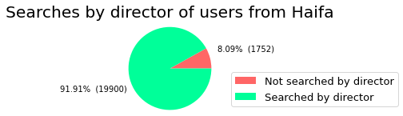

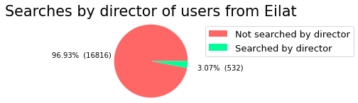

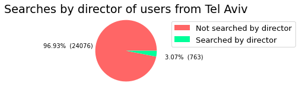

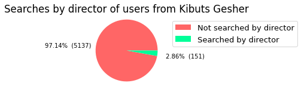

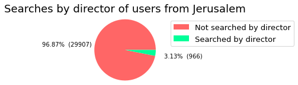

```python
#insight4
queries_user = queries.join(users, queries.user_id == users.user_id)
directors = queries_user.groupBy("user_location","director").count()

#haifa
directors_by_haifa = queries_user.groupBy("user_location","director").count().\
sort(col("count").desc()).filter(queries_user['user_location']=="Haifa").\
drop(queries_user.user_location)
searched_directors_by_haifa = directors_by_haifa.\
where(directors_by_haifa.director != "[]").groupBy().sum()
not_directors_by_haifa = directors_by_haifa.\
where(directors_by_haifa.director == "[]").drop(directors_by_haifa.director)
df_directors_by_haifa = searched_directors_by_haifa.toPandas()
df_not_directors_by_haifa = not_directors_by_haifa.toPandas()
c = df_not_directors_by_haifa['count'].to_list() +\
df_directors_by_haifa['sum(count)'].to_list()
colors5 = ['#ff6666','#00ff99']
label = ["Not searched by director", "Searched by director"]
plt.figure(figsize = (3,3))
pie = plt.pie(c, labels = None, autopct=make_autopct(c), pctdistance=1.9,\
              radius = 2, colors = colors5)
plt.title("Searches by director of users from Haifa",\
          fontdict={'fontsize': 20.2}, y = 1.4)
plt.legend(pie[0],label, bbox_to_anchor=(1.5,0.5), loc="upper right",\
           fontsize=13, bbox_transform=plt.gcf().transFigure)
plt.subplots_adjust(left=0.0, bottom=0.1, right=0.3)
plt.show()
#eilat
directors_by_eilat = queries_user.groupBy("user_location","director").count().\
sort(col("count").desc()).filter(queries_user['user_location'] == "Eilat").\
drop(queries_user.user_location)
searched_directors_by_eilat = directors_by_eilat.\
where(directors_by_eilat.director != "[]").groupBy().sum()
not_directors_by_eilat = directors_by_eilat.\
where(directors_by_eilat.director == "[]").drop(directors_by_eilat.director)
df_directors_by_eilat = searched_directors_by_eilat.toPandas()
df_not_directors_by_eilat = not_directors_by_eilat.toPandas()
c = df_not_directors_by_eilat['count'].to_list() +\
 df_directors_by_eilat['sum(count)'].to_list()
plt.figure(figsize = (3,3))
pie = plt.pie(c, labels = None, autopct=make_autopct(c), pctdistance=1.9,\
              radius = 2, colors = colors5)
plt.title("Searches by director of users from Eilat",\
          fontdict={'fontsize': 20.7}, y = 1.4)
plt.legend(pie[0],label, bbox_to_anchor=(1.5,0.75), loc="upper right",\
           fontsize=13, bbox_transform=plt.gcf().transFigure)
plt.subplots_adjust(left=0.0, bottom=0.1, right=0.3)
plt.show()

#tel aviv
directors_by_tel_aviv=queries_user.groupBy("user_location","director").count().\
sort(col("count").desc()).filter(queries_user['user_location'] =="Tel Aviv").\
drop(queries_user.user_location)
searched_directors_by_tel_aviv = directors_by_tel_aviv.\
where(directors_by_tel_aviv.director != "[]").groupBy().sum()
not_directors_by_tel_aviv = directors_by_tel_aviv.\
where(directors_by_tel_aviv.director=="[]").drop(directors_by_tel_aviv.director)
df_directors_by_tel_aviv = searched_directors_by_tel_aviv.toPandas()
df_not_directors_by_tel_aviv = not_directors_by_tel_aviv.toPandas()
c = df_not_directors_by_tel_aviv['count'].to_list() +\
 df_directors_by_tel_aviv['sum(count)'].to_list()
plt.figure(figsize = (3,3))
pie = plt.pie(c, labels = None, autopct=make_autopct(c), pctdistance=1.9,\
              radius = 2, colors = colors5)
plt.title("Searches by director of users from Tel Aviv",\
          fontdict={'fontsize': 19.3}, y = 1.4)
plt.legend(pie[0],label, bbox_to_anchor=(1.5,0.75),loc="upper right",\
           fontsize=13, bbox_transform=plt.gcf().transFigure)
plt.subplots_adjust(left=0.0, bottom=0.1, right=0.3)
plt.show()

#kibuts gesher
directors_by_kibuts_gesher = queries_user.groupBy("user_location","director").\
count().sort(col("count").desc()).filter(queries_user['user_location']==\
                              "Kibuts Gesher").drop(queries_user.user_location)
searched_directors_by_kibuts_gesher = directors_by_kibuts_gesher.\
where(directors_by_kibuts_gesher.director != "[]").groupBy().sum()
not_directors_by_kibuts_gesher = directors_by_kibuts_gesher.\
where(directors_by_kibuts_gesher.director == "[]").\
drop(directors_by_kibuts_gesher.director)
df_directors_by_kibuts_gesher = searched_directors_by_kibuts_gesher.toPandas()
df_not_directors_by_kibuts_gesher = not_directors_by_kibuts_gesher.toPandas()
c = df_not_directors_by_kibuts_gesher['count'].to_list() +\
 df_directors_by_kibuts_gesher['sum(count)'].to_list()
plt.figure(figsize = (3,3))
pie = plt.pie(c, labels = None, autopct=make_autopct(c), pctdistance=1.9,\
              radius = 2, colors = colors5)
plt.title("Searches by director of users from Kibuts Gesher",\
          fontdict={'fontsize': 16.65}, y = 1.4)
plt.legend(pie[0],label, bbox_to_anchor=(1.5,0.75), loc="upper right",\
           fontsize=13, bbox_transform=plt.gcf().transFigure)
plt.subplots_adjust(left=0.0, bottom=0.1, right=0.3)
plt.show()

#jerusalem
directors_by_jerusalem = queries_user.groupBy("user_location","director").\
count().sort(col("count").desc()).filter(queries_user['user_location']==\
                                  "Jerusalem").drop(queries_user.user_location)
searched_directors_by_jerusalem = directors_by_jerusalem.\
where(directors_by_jerusalem.director != "[]").groupBy().sum()
not_directors_by_jerusalem = directors_by_jerusalem.\
where(directors_by_jerusalem.director=="[]").\
drop(directors_by_jerusalem.director)
df_directors_by_jerusalem = searched_directors_by_jerusalem.toPandas()
df_not_directors_by_jerusalem = not_directors_by_jerusalem.toPandas()
c = df_not_directors_by_jerusalem['count'].to_list() +\
 df_directors_by_jerusalem['sum(count)'].to_list()
plt.figure(figsize = (3,3))
pie = plt.pie(c, labels = None, autopct=make_autopct(c), pctdistance=1.9,\
              radius = 2, colors = colors5)
plt.title("Searches by director of users from Jerusalem",\
          fontdict={'fontsize': 18.1}, y = 1.4)
plt.legend(pie[0],label, bbox_to_anchor=(1.5,0.75), loc="upper right",\
           fontsize=13, bbox_transform=plt.gcf().transFigure)
plt.subplots_adjust(left=0.0, bottom=0.1, right=0.3)
plt.show()
```

### We can see that:

- Users from Haifa are heavily searching for movies by directors (users from other cities significantly less)

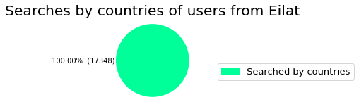

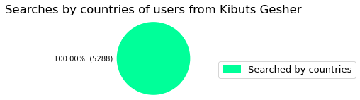

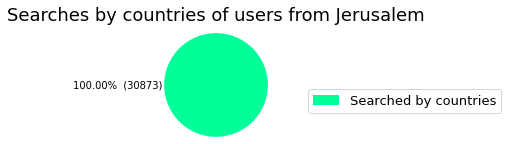

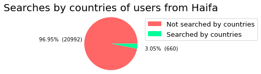

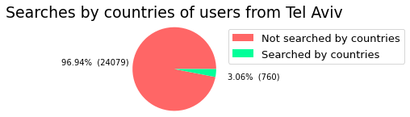

```python
#insight5
queries_user = queries.join(users, queries.user_id == users.user_id)
country_by_eilat = queries_user.groupBy("user_location","country").count().\
sort(col("count").desc()).filter(queries_user['user_location'] == "Eilat").\
drop(queries_user.user_location).withColumnRenamed("count","Number_of_queries")\
.withColumnRenamed("country", "Countries")
country_by_kibuts_gesher = queries_user.groupBy("user_location","country").\
count().sort(col("count").desc()).filter(queries_user['user_location'] ==\
"Kibuts Gesher").drop(queries_user.user_location).\
withColumnRenamed("count", "Number_of_queries").\
withColumnRenamed("country", "Countries")
country_by_jerusalem = queries_user.groupBy("user_location","country").count().\
sort(col("count").desc()).filter(queries_user['user_location'] == "Jerusalem").\
drop(queries_user.user_location).withColumnRenamed("count","Number_of_queries")\
.withColumnRenamed("country", "Countries")
country_by_tel_aviv = queries_user.groupBy("user_location","country").count().\
sort(col("count").desc()).filter(queries_user['user_location'] == "Tel Aviv").\
drop(queries_user.user_location).withColumnRenamed("count","Number_of_queries")\
.withColumnRenamed("country", "Countries")
country_by_haifa = queries_user.groupBy("user_location","country").count().\
sort(col("count").desc()).filter(queries_user['user_location'] == "Haifa").\
drop(queries_user.user_location).withColumnRenamed("count","Number_of_queries")\
.withColumnRenamed("country", "Countries")

#eilat
searched_countries_by_eilat = country_by_eilat.\
where(country_by_eilat.Countries != "[]").groupBy().sum()
not_countries_by_eilat = country_by_eilat.\
where(country_by_eilat.Countries == "[]").drop(country_by_eilat.Countries)
df_searched_countries_by_eilat = searched_countries_by_eilat.toPandas()
df_not_countries_by_eilat = not_countries_by_eilat.toPandas()
c = df_not_countries_by_eilat['Number_of_queries'].to_list() +\
 df_searched_countries_by_eilat['sum(Number_of_queries)'].to_list()
plt.figure(figsize = (3,3))
colors6 = ["#00ff99"]
label1 = ["Searched by countries"]
pie = plt.pie(c, labels = None, autopct=make_autopct(c), pctdistance=1.9,\
              radius = 2, colors = colors6)
plt.title("Searches by countries of users from Eilat",\
          fontdict={'fontsize': 20.2}, y = 1.4)
plt.legend(pie[0],label1, bbox_to_anchor=(1.5,0.5),\
          loc="upper right", fontsize=13, bbox_transform=plt.gcf().transFigure)
plt.subplots_adjust(left=0.0, bottom=0.1, right=0.3)
plt.show()

#kibuts gesher
searched_countries_by_kibuts_gesher = country_by_kibuts_gesher.\
where(country_by_kibuts_gesher.Countries != "[]").groupBy().sum()
not_countries_by_kibuts_gesher = country_by_kibuts_gesher.\
where(country_by_kibuts_gesher.Countries=="[]").\
drop(country_by_kibuts_gesher.Countries)
df_searched_countries_by_kibuts_gesher = searched_countries_by_kibuts_gesher.toPandas()
df_not_countries_by_kibuts_gesher = not_countries_by_kibuts_gesher.toPandas()
c = df_not_countries_by_kibuts_gesher['Number_of_queries'].to_list() +\
 df_searched_countries_by_kibuts_gesher['sum(Number_of_queries)'].to_list()
plt.figure(figsize = (3,3))
pie = plt.pie(c, labels = None, autopct=make_autopct(c), pctdistance=1.9,\
              radius = 2, colors = colors6)
plt.title("Searches by countries of users from Kibuts Gesher",\
          fontdict={'fontsize': 16.45}, y = 1.4)
plt.legend(pie[0],label1, bbox_to_anchor=(1.5,0.5), loc="upper right",\
           fontsize=13, bbox_transform=plt.gcf().transFigure)
plt.subplots_adjust(left=0.0, bottom=0.1, right=0.3)
plt.show()

#jerusalem
searched_countries_by_jerusalem = country_by_jerusalem.\
where(country_by_jerusalem.Countries != "[]").groupBy().sum()
not_countries_by_jerusalem = country_by_jerusalem.\
where(country_by_jerusalem.Countries=="[]").drop(country_by_jerusalem.Countries)
df_searched_countries_by_jerusalem = searched_countries_by_jerusalem.toPandas()
df_not_countries_by_jerusalem = not_countries_by_jerusalem.toPandas()
c = df_not_countries_by_jerusalem['Number_of_queries'].to_list() +\
 df_searched_countries_by_jerusalem['sum(Number_of_queries)'].to_list()
plt.figure(figsize = (3,3))
pie = plt.pie(c, labels = None, autopct=make_autopct(c), pctdistance=1.9,\
              radius = 2, colors = colors6)
plt.title("Searches by countries of users from Jerusalem",\
          fontdict={'fontsize': 17.9}, y = 1.4)
plt.legend(pie[0],label1, bbox_to_anchor=(1.5,0.5), loc="upper right",\
           fontsize=13, bbox_transform=plt.gcf().transFigure)
plt.subplots_adjust(left=0.0, bottom=0.1, right=0.3)
plt.show()

#haifa
searched_countries_by_haifa = country_by_haifa.\
where(country_by_haifa.Countries != "[]").groupBy().sum()
not_countries_by_haifa = country_by_haifa.\
where(country_by_haifa.Countries == "[]").drop(country_by_haifa.Countries)
df_searched_countries_by_haifa = searched_countries_by_haifa.toPandas()
df_not_countries_by_haifa = not_countries_by_haifa.toPandas()
c = df_not_countries_by_haifa['Number_of_queries'].to_list() +\
 df_searched_countries_by_haifa['sum(Number_of_queries)'].to_list()
colors7 = ['#ff6666','#00ff99']
label = ["Not searched by countries", "Searched by countries"]
plt.figure(figsize = (3,3))
pie = plt.pie(c, labels = None, autopct=make_autopct(c), pctdistance=1.9,\
              radius = 2, colors = colors7)
plt.title("Searches by countries of users from Haifa",\
          fontdict={'fontsize': 19.9}, y = 1.4)
plt.legend(pie[0],label, bbox_to_anchor=(1.5,0.75), loc="upper right",\
           fontsize=13, bbox_transform=plt.gcf().transFigure)
plt.subplots_adjust(left=0.0, bottom=0.1, right=0.3)
plt.show()

#tel aviv
searched_countries_by_tel_aviv = country_by_tel_aviv.\
where(country_by_tel_aviv.Countries != "[]").groupBy().sum()
not_countries_by_tel_aviv = country_by_tel_aviv.\
where(country_by_tel_aviv.Countries == "[]").drop(country_by_tel_aviv.Countries)
df_searched_countries_by_tel_aviv = searched_countries_by_tel_aviv.toPandas()
df_not_countries_by_tel_aviv = not_countries_by_tel_aviv.toPandas()
c = df_not_countries_by_tel_aviv['Number_of_queries'].to_list() +\
 df_searched_countries_by_tel_aviv['sum(Number_of_queries)'].to_list()
plt.figure(figsize = (3,3))
pie = plt.pie(c, labels = None, autopct=make_autopct(c), pctdistance=1.9,\
              radius = 2, colors = colors7)
plt.title("Searches by countries of users from Tel Aviv",\
          fontdict={'fontsize': 18.9}, y = 1.4)
plt.legend(pie[0],label, bbox_to_anchor=(1.5,0.75), loc="upper right",\
           fontsize=13, bbox_transform=plt.gcf().transFigure)
plt.subplots_adjust(left=0.0, bottom=0.1, right=0.3)
plt.show()
```

### We can see that:

- Users from Eilat, Kibuts Gesher, Jerusalem are **always** searching for movies accroding to the countries it was produced in (Haifa and Tel Aviv significantly less)

```python
#how we found insight6
print("Top 5 languages searching:")
queries_location = users.join(queries, users.user_id == queries.user_id)
each_cities2=['Eilat', 'Jerusalem', 'Tel Aviv', 'Haifa', 'Kibuts Gesher']
for c in each_cities2:
            lan_amount = queries_location.filter(queries_location.user_location.contains(c)).select('lang').rdd.flatMap(lambda x: x[0][1:-1].split(', ')).countByValue().items()
            sortedd=[]
            for l in lan_amount:
                sortedd.append(l)
            sortedd.sort(key=lambda x: x[1] , reverse= True)
            print()
            print(f"Users from {c} searched for:")
            print(sortedd[0:5])
```

```
Top 5 languages searching:

Users from Eilat searched for:
[("'English'", 17348), ("'Bokmål'", 90), ("''", 85), ("'Azərbaycan'", 85), ("'Norsk'", 82)]

Users from Jerusalem searched for:
[("'English'", 30873), ("'עִבְרִית'", 26261), ("'Català'", 43), ("'Pусский'", 42), ("'Íslenska'", 42)]

Users from Tel Aviv searched for:
[("'English'", 24839), ("'فارسی'", 130), ("'suomi'", 126), ("'Română'", 125), ("'Pусский'", 114)]

Users from Haifa searched for:
[("'English'", 21652), ("'??????'", 108), ("'Esperanto'", 105), ("'Català'", 103), ("'हिन्दी'", 102)]

Users from Kibuts Gesher searched for:
[("'English'", 5288), ("'Deutsch'", 49), ("'Íslenska'", 48), ("'Hrvatski'", 48), ("'Bamanankan'", 46)]
```

### We can see that:

- The second most searched language is Hebrew and the majority who searched for it are users who live in Jerusalem
- From the third language onwards it is no longer something significant

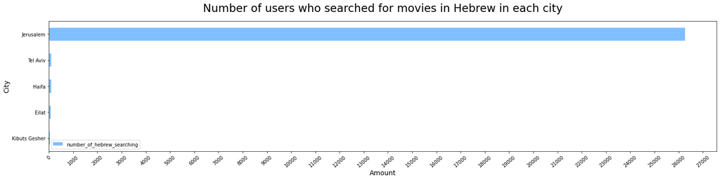

```python
#insight6
queries_location = users.join(queries, users.user_id == queries.user_id)
queries_location_hebrew = queries_location.select('lang', 'user_location').\
where("lang like '%עִבְ%'")
queries_location_hebrew_1 = queries_location_hebrew.groupBy("user_location",\
"lang").count().sort(col("count").desc())
queries_location_hebrew = queries_location_hebrew_1.groupBy("user_location").\
sum("count").sort("sum(count)").\
withColumnRenamed("sum(count)", "number_of_hebrew_searching")
df = queries_location_hebrew.toPandas()

df.plot(kind='barh', x="user_location", color='#80bfff', figsize=(25, 5),\
        xticks = range(0,28000,1000))
plt.title("Number of users who searched for movies in Hebrew in each city",\
          fontdict={'fontsize': 23}, y = 1.05)
plt.xlabel("Amount", fontdict={'fontsize': 14})
plt.ylabel("City", fontdict={'fontsize': 14})
plt.xticks(rotation=40, horizontalalignment="center")
plt.show()
```

### We can see that:

- Users from Jerusalem are searching for movies in Hebrew significantly more than users in other cities

```python
#how we found insight7
print("Top 5 production countries searching:")
queries_location = users.join(queries, users.user_id == queries.user_id)
each_cities2=['Eilat', 'Jerusalem', 'Tel Aviv', 'Haifa', 'Kibuts Gesher']
for c in each_cities2:
            lan_amount = queries_location.filter(queries_location.user_location.contains(c)).select('country').rdd.flatMap(lambda x: x[0][1:-1].split(', ')).countByValue().items()
            sortedd=[]
            for l in lan_amount:
                sortedd.append(l)
            sortedd.sort(key=lambda x: x[1] , reverse= True)
            print()
            print(f" Users from {c} searched for:")
            print(sortedd[0:5])
```

```
Top 5 production countries searching:

 Users from Eilat searched for:
[("'Chad'", 251), ("'Cuba'", 247), ("'Serbia and Montenegro'", 245), ("'Uruguay'", 245), ("'Liberia'", 240)]

 Users from Jerusalem searched for:
[("'Israel'", 24802), ("'Sri Lanka'", 274), ("'Iceland'", 263), ("'Bangladesh'", 259), ("'Lithuania'", 258)]

 Users from Tel Aviv searched for:
[('', 24079), ("'Angola'", 11), ("'Venezuela'", 10), ("'Czechoslovakia'", 10), ("'United States Minor Outlying Islands'", 9)]

 Users from Haifa searched for:
[('', 20992), ("'Hungary'", 12), ("'Bulgaria'", 10), ("'Chad'", 10), ("'Guatemala'", 9)]

 Users from Kibuts Gesher searched for:
[("'Sweden'", 87), ("'Libyan Arab Jamahiriya'", 87), ("'Mali'", 85), ("'Kenya'", 85), ("'Chad'", 85)]
```

### We can see that:

- The most searched production country is Israel by users from Jerusalem.

[figure not shown]

```python
#insight7
queries_location = users.join(queries, users.user_id == queries.user_id)
queries_location_israel = queries_location.select('country', 'user_location').\
where("country like '%Israel%'")
queries_location_israel_1 = queries_location_israel.groupBy("user_location",\
"country").count().sort(col("count").desc())
queries_location_israel = queries_location_israel_1.groupBy("user_location").\
sum("count").sort("sum(count)").\
withColumnRenamed("sum(count)", "number_of_Israel_searching")
df = queries_location_hebrew.toPandas()

df.plot(kind='barh', x="user_location", color='#80bfff', figsize=(25, 5),\
        xticks = range(0,28000,1000))
plt.title("Number of users who searched for movies that were produced in Israel in each city",\
          fontdict={'fontsize': 23}, y = 1.05)
plt.xlabel("Amount", fontdict={'fontsize': 14})
plt.ylabel("City", fontdict={'fontsize': 14})
plt.xticks(rotation=40, horizontalalignment="center")
plt.show()
```

### We can see that:

- Users from Jerusalem are searching for movies that were produced in Israel significantly more than users in other cities

```python
#insight8
queries_location = users.join(queries, users.user_id == queries.user_id)
queries_year = queries_location.select('user_location', 'from_realese_date')
oldest_year = queries_year.select('from_realese_date').rdd.reduce(lambda x, y: min(x, y))
print(f"The oldest year in queries is {oldest_year['from_realese_date']}")
print()
each_location = ['Eilat', 'Jerusalem', 'Tel Aviv', 'Haifa', 'Kibuts Gesher']
for city in each_location:
    oldest_year=queries_year.filter(queries_year.user_location.contains(city)).\
    select('from_realese_date').rdd.reduce(lambda x, y: min(x, y))
    print(f"The oldest year users from {city} searched for is {oldest_year['from_realese_date']}")
```

```
The oldest year in queries is 1990

The oldest year users from Eilat searched for is 1990
The oldest year users from Jerusalem searched for is 1990
The oldest year users from Tel Aviv searched for is 2010
The oldest year users from Haifa searched for is 2010
The oldest year users from Kibuts Gesher searched for is 1990
```

### We can see that:

- The oldest year all users searched for was 1990
- For users from Haifa and Tel Aviv the oldest year they searched for was 2010

```python
#insight9
print("Top 5 production companies searching:")
queries_location = users.join(queries, users.user_id == queries.user_id)
each_cities2=['Eilat', 'Jerusalem', 'Tel Aviv', 'Haifa', 'Kibuts Gesher']
for c in each_cities2:
            lan_amount = queries_location.filter(queries_location.user_location.contains(c)).select('production_company').rdd.flatMap(lambda x: x[0][1:-1].split(', ')).countByValue().items()
            sortedd=[]
            for l in lan_amount:
                sortedd.append(l)
            sortedd.sort(key=lambda x: x[1] , reverse= True)
            print()
            print(f" Users from {c} searched for:")
            print(sortedd[0:5])
```

```
Top 5 production companies searching:

 Users from Eilat searched for:
[("'Pixar Animation Studios'", 8725), ("'Walt Disney Pictures'", 8648), ("'Warner Bros'", 8605), ("The'", 59), ("Inc.'", 13)]

 Users from Jerusalem searched for:
[("The'", 99), ("Ltd.'", 34), ("Inc.'", 32), ("A.I.E.'", 12), ("'Bona Fide Productions'", 9)]

 Users from Tel Aviv searched for:
[("The'", 138), ("Ltd.'", 42), ("Inc.'", 39), ("A.I.E.'", 13), ("LLC'", 11)]

 Users from Haifa searched for:
[("The'", 120), ("Ltd.'", 34), ("Inc.'", 26), ("'FilmHaven Entertainment'", 9), ("A.I.E.'", 9)]

 Users from Kibuts Gesher searched for:
[("The'", 19), ("Ltd.'", 8), ("'Yleisradio (YLE)'", 4), ("'Svenska Biografteatern AB'", 4), ("'Wide Eye Films'", 4)]
```

### We can see that:

- Users from Eilat search a lot by production companies, espically by:
  - Pixar Animation Studios
  - Walt Disney Pictures
  - Warner Bros

```python
#insight10
print("Top 5 genres searching:")
queries_location = users.join(queries, users.user_id == queries.user_id)
each_cities2=['Eilat', 'Jerusalem', 'Tel Aviv', 'Haifa', 'Kibuts Gesher']
for c in each_cities2:
            lan_amount = queries_location.filter(queries_location.user_location.contains(c)).select('genres').rdd.flatMap(lambda x: x[0][1:-1].split(', ')).countByValue().items()
            sortedd=[]
            for l in lan_amount:
                sortedd.append(l)
            sortedd.sort(key=lambda x: x[1] , reverse= True)
            print()
            print(f" Users from {c} searched for:")
            print(sortedd[0:5])
```

```
Top 5 genres searching:

 Users from Eilat searched for:
[("'War'", 1788), ("'Action'", 1776), ("'Family'", 1762), ("'TV Movie'", 1762), ("'Foreign'", 1760)]

 Users from Jerusalem searched for:
[("'Drama'", 2495), ("'Comedy'", 2479), ("'Mystery'", 2478), ("'Science Fiction'", 2466), ("'Animation'", 2456)]

 Users from Tel Aviv searched for:
[("'Action'", 20086), ("'Drama'", 2420), ("'Foreign'", 1302), ("'Science Fiction'", 1300), ("'War'", 1296)]

 Users from Haifa searched for:
[("'Drama'", 17764), ("'Romance'", 2226), ("'Thriller'", 2219), ("'Adventure'", 2217), ("'Animation'", 2197)]

 Users from Kibuts Gesher searched for:
[("'Family'", 2607), ("'Documentary'", 2591), ("'War'", 185), ("'Science Fiction'", 182), ("'Western'", 174)]
```

### We can see that:

- Users from Tel Aviv search a lot by the "Action" genre.
- Users from Haifa search a lot b the "Drama" genre (how we do not have enough drama from the wild boars?).
- Users from kibuts Gesher search a lot by the "Family" and "Documentary" genres

### Optimizer:

1. Calculates the average amount of entries in each field sort and separated by residents of each city. This is used to find the most optimized way to sort and secondary sort database (allowing binary search and minimizing amount of repeat big searches).

```python
#optimizer1
queries_location = queries.join(users , users.user_id == queries.user_id)
each_cities2=['Eilat', 'Jerusalem', 'Tel Aviv', 'Haifa', 'Kibuts Gesher']
column_select = ['genres', 'lang', 'actors', 'director', 'country', 'from_realese_date', 'production_company','user_location']
column_to = ['genres', 'lang', 'actors', 'director', 'country', 'from_realese_date', 'production_company']
twoD_dic = {}
for c in each_cities2:
    twoD_dic[c] = {}
    df_c = queries_location.select(column_select).filter(queries_location.user_location.contains(c))
    tot = df_c.count()
    for coll in column_to:
        twoD_dic[c][coll] = tot
def func(x):
    if x == "[]":
        return 0
    return x.count(',') + 1
funcc = f.udf(lambda x: func(x))
queries_1 = queries_location.select(column_select)
for c in column_to:
    queries_1 = queries_1.withColumn(c, funcc(c))
printt = {}
for city in each_cities2:
    printt[city] = []
    for c in column_to:
        resu =queries_1.filter(queries_1.user_location.contains(city)).select(c).rdd.map(lambda x: (1, int(x[0]))).reduceByKey(lambda x, y: x + y).collect()
        resu=resu[0][1]
        printt[city].append(
            f"{c}:{round(resu/twoD_dic[city][coll],2)}")
for city in each_cities2:
    print(f"Users from {city} search in an average query :")
    for p in printt[city]:
        print(p, end=" ,")
    print("\n")
```

```
Users from Eilat search in an average query :
genres:2.0 ,lang:1.29 ,actors:0.0 ,director:0.05 ,country:2.0 ,from_realese_date:1.0 ,production_company:2.5 ,

Users from Jerusalem search in an average query :
genres:1.56 ,lang:1.93 ,actors:1.9 ,director:0.05 ,country:1.99 ,from_realese_date:1.0 ,production_company:1.51 ,

Users from Tel Aviv search in an average query :
genres:1.81 ,lang:1.3 ,actors:0.89 ,director:0.05 ,country:0.03 ,from_realese_date:1.0 ,production_company:2.02 ,

Users from Haifa search in an average query :
genres:2.72 ,lang:1.3 ,actors:0.88 ,director:1.38 ,country:0.03 ,from_realese_date:1.0 ,production_company:2.01 ,

Users from Kibuts Gesher search in an average query :
genres:1.52 ,lang:1.51 ,actors:0.87 ,director:0.04 ,country:2.0 ,from_realese_date:1.0 ,production_company:1.5 ,
```